# NLP

## 阅读理解

### 理解和使用自然语言处理之终极指南

#### **Introduction to Natural Language Processing**，自然语言处理介绍

**NLP**是数据科学的一个分支，包括智能和高效地从文本数据中分析、理解和导出信息的系统流程。通过NLP及其组成部分，企业可以组织海量文本数据块、执行许多自动化任务、并解决广泛问题，如自动摘要、机器翻译、命名实体识别、关系抽取、情感分析、语音识别、主题分割等。

#### **Text Preprocessing**，文本预处理

- **Noise Removal**，噪声去除

  **问题说明**，与数据上下文和最终输出无关的文本片段（可统一称作 噪声）

  **主要包括**，语言停用词（常用词 is am the of等）、标点符号、URL、标签等

  **通常做法**，准备 噪声实体字典，通过标记符号来迭代文本对象；或者，使用正则表达式来进行替换

```python
# Sample code to remove noisy words from a text
noise_list = ["is", "a", "this", "..."]

def _remove_noise(input_text):

    words = input_text.split()

    noise_free_words = [word for word in words if word not in noise_list]
    noise_free_text = " ".join(noise_free_words)

    return noise_free_text

_remove_noise("this is a sample text")
```

```
'sample text'
```

```python
# Sample code to remove a regex pattern
import re
regex_pattern = "#[A-Za-z0-9\w]*"

def _remove_regex(input_text, regex_pattern):

    urls = re.finditer(regex_pattern, input_text)

    for i in urls:

        input_text = re.sub(i.group().strip(), '', input_text)

    return input_text

_remove_regex("remove this #hashtag #hashtag2 from analytics vidhya", regex_pattern)
```

```
'remove this  2 from analytics vidhya'
```

- **Lexicon Normalization**，词汇标准化

  **问题说明**，词语（尤其是英文单词）表现的多重表征，如何把一个词的所有差异转换成它们的标准化形式

  **主要包括**，后缀（ing、ly、es、s、er）、词根（语料学习获得）

  **通常做法**，stemming，词干提取，基于规则的从一个词剥离后缀的过程（ing、es..）;lemmatization，词变体归类，有组织且有步骤获取词的词根形式的过程，即词汇用法（单词的词典重要性）和形态逻辑分析（词汇结构和语法关系）

```python
from nltk.stem.porter import PorterStemmer

stem = PorterStemmer()
word = "multiplying"

stem.stem(word)
```

```
'multipli'
```

```python
from nltk.stem.wordnet import WordNetLemmatizer

lem = WordNetLemmatizer()

word = "multiplying"

lem.lemmatize(word, "v")
```

```
'multiply'
```

- **Object Standardization**，对象标准化

  **问题说明**，任何标准语义字典中不存在的单词或短语（可统一称作 碎片）

  **主要包括**，缩写词，口语俚语等

  **通常做法**，借助正则表达式和手工编写的数据词典

```python
lookup_dict = {'rt':'Retweet', 'dm':'direct message', "awsm" : "awesome", "luv" :"love"}

def _lookup_words(input_text):

    words = input_text.split()

    new_words = []

    for word in words:

        if word.lower() in lookup_dict:

            word = lookup_dict[word.lower()]

        new_words.append(word)

    new_text = " ".join(new_words)
    return new_text

_lookup_words("RT this is a retweeted tweet by Shivam Bansal")
```

```
'Retweet this is a retweeted tweet by Shivam Bansal'
```

#### **Text to Features**，文本到特征

- Syntactic Parsing，句法解析

句法解析涉及句中**单词的语法**和显示这些**单词间关系的排列方法**的分析，依存语法和部分语音标签是文本句法的重要属性。

**Dependency Parsing**，DP，依存语法，通过分析语言单位内成分之间的依存关系揭示其句法结构。 直观来讲，依存句法分析识别句子中的“主谓宾”、“定状补”这些语法成分，并分析各成分之间的关系。

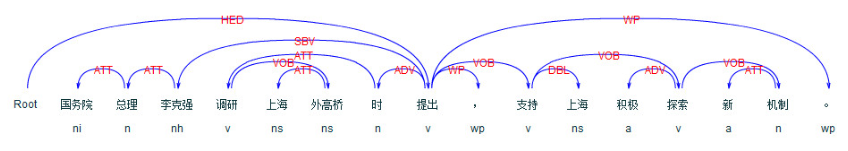

```python
from IPython.display import Image
Image("images/dependency_parsing.png")
```

**Part Of Speech**，POS，词性标签定义一个词的用法和功能。主要用于词义消歧（book my flight, I will read this book。不同意义的book）、提高基于词的特征值（book my flight, I will read this book。book_VB、bookNN），标准化和词变体归类、有效的停用词去除（IN - within，upon，except；MD - may，must）。

```python
from nltk import word_tokenize, pos_tag

text = "I am learning Natural Language Processing on Analytics Vidhya"

tokens = word_tokenize(text)

pos_tag(tokens)
```

```
[('I', 'PRP'),
 ('am', 'VBP'),
 ('learning', 'VBG'),
 ('Natural', 'NNP'),
 ('Language', 'NNP'),
 ('Processing', 'NNP'),
 ('on', 'IN'),
 ('Analytics', 'NNP'),
 ('Vidhya', 'NNP')]
```

- **Entity Extraction**，实体提取

**实体**，句子中最重要的句块 名次短语、动词短语等。

**Named Entity Recognition**，NER，命名实体识别，检测如人名、地名、公司名等命名实体的过程。

典型NER模型一般包括：

```
* 名词短语识别，涉及使用依存解析和词性标注从文本中提取所有名次短语
* 短语分类，将所有被提取名词短语划分为所属相应类别的分类步骤（谷歌地图API提供了消除歧义位置；DBpedia、wikipedia开放数据库可用来识别个人姓名或公司名称；结合不同信息员的查找表和词典进行精确查找）
* 实体消歧，有时可能出现误判分类，通常在分类结果上增加验证层（可以的方案是 流行的知识图 谷歌、IBM沃森、维基百科等）
```

**Topic Modeling**，主题模型 是一个存在于文本语料库中主题的自动识别过程，它以无监督方式推导出语料库中的隐含模式，通常使用 LDA，隐含狄利克雷分配

```python
doc1 = "Sugar is bad to consume. My sister likes to have sugar, but not my father."

doc2 = "My father spends a lot of time driving my sister around to dance practice."

doc3 = "Doctors suggest that driving may cause increased stress and blood pressure."

doc_complete = [doc1, doc2, doc3]

doc_clean = [doc.split() for doc in doc_complete]

import gensim

from gensim import corpora

# Creating the term dictionary of our corpus, where every unique term is assigned an index.

dictionary = corpora.Dictionary(doc_clean)

# Converting list of documents (corpus) into Document Term Matrix using dictionary prepared above.

doc_term_matrix = [dictionary.doc2bow(doc) for doc in doc_clean]

# Creating the object for LDA model using gensim library

Lda = gensim.models.ldamodel.LdaModel

# Running and Training LDA model on the document term matrix

ldamodel = Lda(doc_term_matrix, num_topics=3, id2word = dictionary, passes=50)

# Results
print(ldamodel.print_topics())
```

[output not shown]

**N-Grams as Features**，N元连续模型

**N-gram**，N个单词（N>1)在一起的组合，相比单词（1gram）包含更多信息，且双单词（n=2）被认为是最重要的特征。

```python
def generate_ngrams(text, n):

    words = text.split()

    output = []

    for i in range(len(words)-n+1):

        output.append(words[i:i+n])

    return output

generate_ngrams('this is a sample text', 2)
```

```
[['this', 'is'], ['is', 'a'], ['a', 'sample'], ['sample', 'text']]
```

- **Statistical Features**，统计特征

文本数据量化为数字

**Term Frequency-Inverse Document Frequency**，词频-逆文档频率

**TF-IDF** 是不考虑精确排序的，在文档中出现词汇的基础上，将文本文件转化为向量模型，是常见的信息检索问题加权模型。

**TF** 的**T**是文档**D**中词项**T**的计数。 **IDF** 是T在语料库中文档数与包含词项T的文档数的比值的对数，详见 TF-IDF相关描述

```python
# 该模型创建一个词汇字典，并给每个单词分配一个索引。输出的每一行包含一个元组（i，j）和一组文档i中索引词j的TF-IDF值

from sklearn.feature_extraction.text import TfidfVectorizer

obj = TfidfVectorizer()

corpus = ['This is sample document.', 'another random document.', 'third sample document text']

X = obj.fit_transform(corpus)

print(X)
```

```
  (0, 7)	0.5844829010200651
  (0, 2)	0.5844829010200651
  (0, 4)	0.444514311537431
  (0, 1)	0.34520501686496574
  (1, 1)	0.3853716274664007
  (1, 0)	0.652490884512534
  (1, 3)	0.652490884512534
  (2, 4)	0.444514311537431
  (2, 1)	0.34520501686496574
  (2, 6)	0.5844829010200651
  (2, 5)	0.5844829010200651
```

**count/Density/Readability Features**，计数/密度/可读性特征

这些功能似乎微不足道，但在学习模型显示了很大影响。一些特征值有：单词数、句子计数、标点符号数和特定行业用词数

- **word Embedding**，text vectors，字嵌入，词向量

**字嵌入**的目的是通过保留语料库中的上下文相似度，来重新对高维字特征定义到低维特征向量，适用于深度学习模型，常用模型有Word2Vec和GloVe。

**Worf2Vec**模型是由Continuous Bag of Words和skip-gram两个浅层神经网络模型组成。首先构建一个词汇训练语料库，然后学习字嵌入表征值。它们可以用来作为ML模型的特征向量，使用余弦相似性技术、词聚类和文本分类技术来测量文本相似性。

```python
from gensim.models import Word2Vec

sentences = [['data', 'science'], ['vidhya', 'science', 'data', 'analytics'],['machine', 'learning'], ['deep', 'learning']]

# train the model on your corpus

model = Word2Vec(sentences, min_count = 1)

print(model.similarity('data', 'science'))
print(model["learning"])
```

```
-0.04795919640313323
[ 6.6688907e-04 -2.6119319e-03  4.3546255e-03 -4.5350613e-03
  1.2770756e-03 -7.3239201e-04 -3.4181210e-03  4.9619093e-03
 -2.6375169e-03  1.3948006e-03  4.2007645e-03 -5.3497276e-04
  2.6891634e-03  4.4442620e-03 -3.7735878e-03  2.3308021e-03
 -5.0027645e-04 -4.1849516e-06  1.9162237e-03 -4.4961781e-03
  1.6264439e-03 -3.7260719e-03  1.3678785e-03  3.8577246e-03
 -3.4150935e-03 -3.7206124e-04 -3.9649876e-03  3.7124555e-03
  1.0556731e-03 -1.5522714e-03 -2.7786046e-03 -4.2261174e-03
 -1.5759919e-03  4.9198470e-03 -4.9266587e-03  3.7977407e-03
 -3.1742691e-03  1.0512494e-04  4.5082429e-03  1.6465181e-03
 -1.3371554e-03 -6.5657974e-04 -1.6628291e-03 -1.8807956e-03
  4.0304824e-03 -1.9526156e-04 -1.6340547e-03 -1.6615066e-03
 -2.6174749e-03 -4.6307459e-03  8.4720814e-04 -5.9949141e-04
 -3.4394057e-03  4.9434169e-03 -1.3300235e-03  4.0773069e-03
  2.3191599e-03  3.3161461e-03  1.2444437e-03  4.3514529e-03
 -1.8203049e-03  3.7174074e-03 -3.7881189e-03  1.0367202e-03
  3.3447039e-05  3.5485295e-03 -4.4318992e-03 -3.9553479e-03
 -3.6866809e-03  1.2574919e-03  1.9037813e-03  1.8180090e-03
  1.9881888e-03  5.9257337e-04  1.9730849e-03  1.3262228e-04
 -9.1045146e-04 -3.4850037e-03 -5.2348687e-04  2.6833429e-03
  8.6057058e-04 -4.6494654e-03 -3.8823565e-03 -2.0066374e-04
 -2.1322458e-03  4.9182344e-03  4.3477295e-03 -4.0164269e-03
 -6.3081196e-04 -4.7315033e-03 -4.8050671e-03 -1.7098216e-03
 -4.1588140e-03 -1.9376479e-03 -1.6067537e-03 -1.1803892e-03
 -4.8469515e-03 -4.9900892e-03 -2.0389222e-04  1.1195826e-03]
```

## 参考

- PYTHON自然语言处理
- [理解和使用自然语言处理之终极指南](https://www.kancloud.cn/hx78/ai/355578)